# Bellabeat Case Study: How Can A Wellness Technology Company Play It Smart?

This case study is the Capstone Project of Google Data Analytics Professional Certificate. The 6 steps of Data Analysis is used to present this analysis.

- Ask
- Prepare
- Process (Data Cleaning)
- Analyze (Data Wrangling)
- Share (Data Visualization)
- Act (Recommendation)

Author: Van Nguyen

# STEP 1: ASK

## 1.1 Background

Bellabeat is a high-tech manufacturer of beautifully-designed health-focused smart products for women since 2013. Inspiring and empowering women with knowledge about their own health and habits, Bellabeat has grown rapidly and quickly positioned itself as a tech-driven wellness company for females.

The co-founder and Chief Creative Officer, Urška Sršen is confident that an analysis of non-Bellebeat consumer data (ie. FitBit fitness tracker usage data) would reveal more opportunities for growth.

## 1.2 Business Task

Analyze FitBit Fitness Tracker Data to gain insights into how consumers are using the FitBit app and discover trends and insights for Bellabeat marketing strategy.

## 1.3 Business Objectives

- What are the trends identified?
- How could these trends apply to Bellabeat customers?
- How could these trends help influence Bellabeat marketing strategy?

## 1.4 Deliverables

- A clear summary of the business task
- A description of all data sources used
- Documentation of any cleaning or manipulation of data
- A summary of analysis
- Supporting visualizations and key findings
- High-level content recommendations based on the analysis

## 1.5 Key Stakeholders

- Urška Sršen: Bellabeat’s cofounder and Chief Creative Officer
- Sando Mur: Mathematician, Bellabeat’s cofounder and key member of the Bellabeat executive team
- Bellabeat marketing analytics team: A team of data analysts guiding Bellabeat's marketing strategy.

# STEP 2: PREPARE

## 2.1 Information about the data source

Data source: FitBit Fitness Tracker Data: public dataset on Kaggle - [Link](https://www.kaggle.com/datasets/arashnic/fitbit)

Information about dataset:

- Sample: 30 eligible Fitbit users consented to the submission of personal tracker data including minute-level output for physical activity, heart rate, and sleep monitoring
- Data collection: survey via Amazon Mechanical Turk between 03.12.2016 - 05.12.2016
- Data Organization and verification: Available to us are 18 CSV documents. Each document represents different quantitative data tracked by Fitbit. Every user has a unique ID and different rows since data is tracked by day and time.

## 2.2 Limitations of the data Set

- Due to the limitation of size (30 users) and not having any demographic information we could encounter a sampling bias. We are not sure if the sample is representative of the population as a whole
- Data collected from year 2016. Users' daily activity, fitness and sleeping habits, diet and food consumption may have changed since then, hence data may not be timely or relevant.

## 2.3 Data selection

Focus is on daily usage of the Fitbit device as it should provide a high-level insight on the usage pattern of smart devices. Thus the following files from the dataset has been selected:

- dailyActivity_merged.csv
- sleepDay_merged.csv
- hourlySteps_merged.csv

# STEP 3: PROCESS

We are using Python to prepare and process the data.

## 3.1 Preparing the Environment

```python
import numpy as np # data arrays
import pandas as pd # data structure and data analysis
import matplotlib.pyplot as plt # data visualization
import seaborn as sns  # data visualization
import datetime as dt # date %time
```

## 3.2 Import dataset

```python
daily_activity = pd.read_csv(r'C:\Users\Admin\OneDrive\Tài liệu\DA Projects\BellaBeat\Raw Data\Fitabase Data 4.12.16-5.12.16\dailyActivity_merged.csv')
sleep = pd.read_csv(r"C:\Users\Admin\OneDrive\Tài liệu\DA Projects\BellaBeat\Raw Data\Fitabase Data 4.12.16-5.12.16\sleepDay_merged.csv")
hourly_steps = pd.read_csv(r'C:\Users\Admin\OneDrive\Tài liệu\DA Projects\BellaBeat\Raw Data\Fitabase Data 4.12.16-5.12.16\hourlySteps_merged.csv')
```

## 3.3 Data Cleaning & Manipulation

```python
# Preview the data set
daily_activity.head()
```

|  | Id | ActivityDate | TotalSteps | TotalDistance | TrackerDistance | LoggedActivitiesDistance | VeryActiveDistance | ModeratelyActiveDistance | LightActiveDistance | SedentaryActiveDistance | VeryActiveMinutes | FairlyActiveMinutes | LightlyActiveMinutes | SedentaryMinutes | Calories |
| --- | --- | --- | --- | --- | --- | --- | --- | --- | --- | --- | --- | --- | --- | --- | --- |
| 0 | 1503960366 | 4/12/2016 | 13162 | 8.50 | 8.50 | 0.0 | 1.88 | 0.55 | 6.06 | 0.0 | 25 | 13 | 328 | 728 | 1985 |
| 1 | 1503960366 | 4/13/2016 | 10735 | 6.97 | 6.97 | 0.0 | 1.57 | 0.69 | 4.71 | 0.0 | 21 | 19 | 217 | 776 | 1797 |
| 2 | 1503960366 | 4/14/2016 | 10460 | 6.74 | 6.74 | 0.0 | 2.44 | 0.40 | 3.91 | 0.0 | 30 | 11 | 181 | 1218 | 1776 |
| 3 | 1503960366 | 4/15/2016 | 9762 | 6.28 | 6.28 | 0.0 | 2.14 | 1.26 | 2.83 | 0.0 | 29 | 34 | 209 | 726 | 1745 |
| 4 | 1503960366 | 4/16/2016 | 12669 | 8.16 | 8.16 | 0.0 | 2.71 | 0.41 | 5.04 | 0.0 | 36 | 10 | 221 | 773 | 1863 |

```python
# Show basic information of the dataset
daily_activity.info()
```

```
<class 'pandas.core.frame.DataFrame'>
RangeIndex: 940 entries, 0 to 939
Data columns (total 15 columns):
 #   Column                    Non-Null Count  Dtype
---  ------                    --------------  -----
 0   Id                        940 non-null    int64
 1   ActivityDate              940 non-null    object
 2   TotalSteps                940 non-null    int64
 3   TotalDistance             940 non-null    float64
 4   TrackerDistance           940 non-null    float64
 5   LoggedActivitiesDistance  940 non-null    float64
 6   VeryActiveDistance        940 non-null    float64
 7   ModeratelyActiveDistance  940 non-null    float64
 8   LightActiveDistance       940 non-null    float64
 9   SedentaryActiveDistance   940 non-null    float64
 10  VeryActiveMinutes         940 non-null    int64
 11  FairlyActiveMinutes       940 non-null    int64
 12  LightlyActiveMinutes      940 non-null    int64
 13  SedentaryMinutes          940 non-null    int64
 14  Calories                  940 non-null    int64
dtypes: float64(7), int64(7), object(1)
memory usage: 110.3+ KB
```

```python
# Check unique ID to confirm whether the dataset has 30 IDs
unique_id_activity = len(daily_activity['Id'].unique())
print('Number of unique ID - activity:' + str(unique_id_activity))

unique_id_sleep = len(sleep['Id'].unique())
print('Number of unique ID - sleep:' + str(unique_id_sleep))

unique_id_steps = len(hourly_steps['Id'].unique())
print('Number of unique ID - hourly_steps:' + str(unique_id_steps))
```

```
Number of unique ID - activity:33
Number of unique ID - sleep:24
Number of unique ID - hourly_steps:33
```

```python
# Check duplicates
dup_rows = daily_activity.duplicated()
dup_rows_sleep = sleep.duplicated()
dup_rows_steps = hourly_steps.duplicated()
print('Number of duplicates - activity:' + str(sum(dup_rows)))
print('Number of duplicates - sleep:' + str(sum(dup_rows_sleep)))
print('Number of duplicates - hourly_steps:' + str(sum(dup_rows_steps)))
```

```
Number of duplicates - activity:0
Number of duplicates - sleep:3
Number of duplicates - hourly_steps:0
```

### From the above observation, we can see that:

- There is no typo, Null or missing values.
- Data frame has 940 rows and 15 columns.
- ActivityDate is wrongly classified as object dtype and has to be converted to datetime64 dtype.
- There are 33 unique IDs, instead of 30 unique IDs as expected from 30 fitness tracker users
- There are 3 duplicates in the 'sleep' dataframe

### The following data manipulation is performed:

- Rename 'ActivityDate' from 'daily_activity' and 'SleepDay' from 'sleep' to 'Date' for merging 2 dataframes later on
- Convert ActivityDate to datatime64 dtype.
- Remove duplicates in the 'sleep' dataframe
- Create new column 'DayOfWeek' by separating the date into day of the week for further analysis.
- Create new columns 'TotalMinute' & 'TotalHour' as the sum of VeryActiveMinutes, FairlyActiveMinutes, LightlyActiveMinutes and SedentaryMinutes.
- Create new column 'TotalHoursAsSleep' from 'TotalMinuteAsleep'
- Merge ActivityDate & Sleep dataframes by Id, ActivityDate
- Rearrange columns for easier reading
- Split 'ActivityHour' (dtype:datetime) in to 2 columns 'Date' & 'Time'

```python
# Rename columns
daily_activity.rename(columns = {'ActivityDate':'Date'}, inplace = True)
sleep.rename(columns = {'SleepDay':'Date'}, inplace = True)
daily_activity.info()
sleep.info()
```

[output not shown]

```python
# Covert data type - Column 'Date' dtype object to datetime
daily_activity['Date'] = pd.to_datetime(daily_activity['Date'])
daily_activity.info()

sleep['Date'] = pd.to_datetime(sleep['Date'])
sleep.info()

hourly_steps['ActivityHour'] = pd.to_datetime(hourly_steps['ActivityHour'])
hourly_steps.info()
```

```
<class 'pandas.core.frame.DataFrame'>
RangeIndex: 940 entries, 0 to 939
Data columns (total 15 columns):
 #   Column                    Non-Null Count  Dtype
---  ------                    --------------  -----
 0   Id                        940 non-null    int64
 1   Date                      940 non-null    datetime64[ns]
 2   TotalSteps                940 non-null    int64
 3   TotalDistance             940 non-null    float64
 4   TrackerDistance           940 non-null    float64
 5   LoggedActivitiesDistance  940 non-null    float64
 6   VeryActiveDistance        940 non-null    float64
 7   ModeratelyActiveDistance  940 non-null    float64
 8   LightActiveDistance       940 non-null    float64
 9   SedentaryActiveDistance   940 non-null    float64
 10  VeryActiveMinutes         940 non-null    int64
 11  FairlyActiveMinutes       940 non-null    int64
 12  LightlyActiveMinutes      940 non-null    int64
 13  SedentaryMinutes          940 non-null    int64
 14  Calories                  940 non-null    int64
dtypes: datetime64[ns](1), float64(7), int64(7)
memory usage: 110.3 KB
<class 'pandas.core.frame.DataFrame'>
RangeIndex: 413 entries, 0 to 412
Data columns (total 5 columns):
 #   Column              Non-Null Count  Dtype
---  ------              --------------  -----
 0   Id                  413 non-null    int64
 1   Date                413 non-null    datetime64[ns]
 2   TotalSleepRecords   413 non-null    int64
 3   TotalMinutesAsleep  413 non-null    int64
 4   TotalTimeInBed      413 non-null    int64
dtypes: datetime64[ns](1), int64(4)
memory usage: 16.3 KB
<class 'pandas.core.frame.DataFrame'>
RangeIndex: 22099 entries, 0 to 22098
Data columns (total 3 columns):
 #   Column        Non-Null Count  Dtype
---  ------        --------------  -----
 0   Id            22099 non-null  int64
 1   ActivityHour  22099 non-null  datetime64[ns]
 2   StepTotal     22099 non-null  int64
dtypes: datetime64[ns](1), int64(2)
memory usage: 518.1 KB
```

```python
# Remove duplicates in "Sleep" dataframe
sleep_unique = sleep.drop_duplicates()
print('Number of duplicates - sleep:' + str(sum(sleep_unique.duplicated())))
```

```
Number of duplicates - sleep:0
```

```python
# Create new columns: 'DayOfWeek', 'TotalMinutes', 'TotalHours'
daily_activity['DayOfWeek'] = daily_activity["Date"].dt.day_name()

daily_activity['TotalMinutes'] = daily_activity['VeryActiveMinutes'] + daily_activity['FairlyActiveMinutes'] + daily_activity['LightlyActiveMinutes'] + daily_activity['SedentaryMinutes']

daily_activity['TotalHours'] = round(daily_activity['TotalMinutes']/60,2)

#View dataframe
daily_activity.head()
```

|  | Id | Date | TotalSteps | TotalDistance | TrackerDistance | LoggedActivitiesDistance | VeryActiveDistance | ModeratelyActiveDistance | LightActiveDistance | SedentaryActiveDistance | VeryActiveMinutes | FairlyActiveMinutes | LightlyActiveMinutes | SedentaryMinutes | Calories | DayOfWeek | TotalMinutes | TotalHours |
| --- | --- | --- | --- | --- | --- | --- | --- | --- | --- | --- | --- | --- | --- | --- | --- | --- | --- | --- |
| 0 | 1503960366 | 2016-04-12 | 13162 | 8.50 | 8.50 | 0.0 | 1.88 | 0.55 | 6.06 | 0.0 | 25 | 13 | 328 | 728 | 1985 | Tuesday | 1094 | 18.23 |
| 1 | 1503960366 | 2016-04-13 | 10735 | 6.97 | 6.97 | 0.0 | 1.57 | 0.69 | 4.71 | 0.0 | 21 | 19 | 217 | 776 | 1797 | Wednesday | 1033 | 17.22 |
| 2 | 1503960366 | 2016-04-14 | 10460 | 6.74 | 6.74 | 0.0 | 2.44 | 0.40 | 3.91 | 0.0 | 30 | 11 | 181 | 1218 | 1776 | Thursday | 1440 | 24.00 |
| 3 | 1503960366 | 2016-04-15 | 9762 | 6.28 | 6.28 | 0.0 | 2.14 | 1.26 | 2.83 | 0.0 | 29 | 34 | 209 | 726 | 1745 | Friday | 998 | 16.63 |
| 4 | 1503960366 | 2016-04-16 | 12669 | 8.16 | 8.16 | 0.0 | 2.71 | 0.41 | 5.04 | 0.0 | 36 | 10 | 221 | 773 | 1863 | Saturday | 1040 | 17.33 |

```python
# Rearrange columns for easier reading
moving_dayow = daily_activity.pop('DayOfWeek') # Move 'DayOfWeek'
daily_activity.insert (2, 'DayOfWeek', moving_dayow)
```

```python
moving_hour = daily_activity.pop('TotalHours') # Move 'TotalHour'
daily_activity.insert (11, 'TotalHours', moving_hour)
```

```python
moving_min = daily_activity.pop('TotalMinutes') # Move 'TotalMinute'
daily_activity.insert (12, 'TotalMinutes', moving_min)
```

```python
#View dataframe
daily_activity.head()
```

|  | Id | Date | DayOfWeek | TotalSteps | TotalDistance | TrackerDistance | LoggedActivitiesDistance | VeryActiveDistance | ModeratelyActiveDistance | LightActiveDistance | SedentaryActiveDistance | TotalHours | TotalMinutes | VeryActiveMinutes | FairlyActiveMinutes | LightlyActiveMinutes | SedentaryMinutes | Calories |
| --- | --- | --- | --- | --- | --- | --- | --- | --- | --- | --- | --- | --- | --- | --- | --- | --- | --- | --- |
| 0 | 1503960366 | 2016-04-12 | Tuesday | 13162 | 8.50 | 8.50 | 0.0 | 1.88 | 0.55 | 6.06 | 0.0 | 18.23 | 1094 | 25 | 13 | 328 | 728 | 1985 |
| 1 | 1503960366 | 2016-04-13 | Wednesday | 10735 | 6.97 | 6.97 | 0.0 | 1.57 | 0.69 | 4.71 | 0.0 | 17.22 | 1033 | 21 | 19 | 217 | 776 | 1797 |
| 2 | 1503960366 | 2016-04-14 | Thursday | 10460 | 6.74 | 6.74 | 0.0 | 2.44 | 0.40 | 3.91 | 0.0 | 24.00 | 1440 | 30 | 11 | 181 | 1218 | 1776 |
| 3 | 1503960366 | 2016-04-15 | Friday | 9762 | 6.28 | 6.28 | 0.0 | 2.14 | 1.26 | 2.83 | 0.0 | 16.63 | 998 | 29 | 34 | 209 | 726 | 1745 |
| 4 | 1503960366 | 2016-04-16 | Saturday | 12669 | 8.16 | 8.16 | 0.0 | 2.71 | 0.41 | 5.04 | 0.0 | 17.33 | 1040 | 36 | 10 | 221 | 773 | 1863 |

```python
# Merge ActivityDate & Sleep dataframes by Id, Date
merged_df = pd.merge(daily_activity, sleep_unique,  how='left', on=['Id','Date'])
merged_df
```

|  | Id | Date | DayOfWeek | TotalSteps | TotalDistance | TrackerDistance | LoggedActivitiesDistance | VeryActiveDistance | ModeratelyActiveDistance | LightActiveDistance | ... | TotalHours | TotalMinutes | VeryActiveMinutes | FairlyActiveMinutes | LightlyActiveMinutes | SedentaryMinutes | Calories | TotalSleepRecords | TotalMinutesAsleep | TotalTimeInBed |
| --- | --- | --- | --- | --- | --- | --- | --- | --- | --- | --- | --- | --- | --- | --- | --- | --- | --- | --- | --- | --- | --- |
| 0 | 1503960366 | 2016-04-12 | Tuesday | 13162 | 8.500000 | 8.500000 | 0.0 | 1.88 | 0.55 | 6.06 | ... | 18.23 | 1094 | 25 | 13 | 328 | 728 | 1985 | 1.0 | 327.0 | 346.0 |
| 1 | 1503960366 | 2016-04-13 | Wednesday | 10735 | 6.970000 | 6.970000 | 0.0 | 1.57 | 0.69 | 4.71 | ... | 17.22 | 1033 | 21 | 19 | 217 | 776 | 1797 | 2.0 | 384.0 | 407.0 |
| 2 | 1503960366 | 2016-04-14 | Thursday | 10460 | 6.740000 | 6.740000 | 0.0 | 2.44 | 0.40 | 3.91 | ... | 24.00 | 1440 | 30 | 11 | 181 | 1218 | 1776 | NaN | NaN | NaN |
| 3 | 1503960366 | 2016-04-15 | Friday | 9762 | 6.280000 | 6.280000 | 0.0 | 2.14 | 1.26 | 2.83 | ... | 16.63 | 998 | 29 | 34 | 209 | 726 | 1745 | 1.0 | 412.0 | 442.0 |
| 4 | 1503960366 | 2016-04-16 | Saturday | 12669 | 8.160000 | 8.160000 | 0.0 | 2.71 | 0.41 | 5.04 | ... | 17.33 | 1040 | 36 | 10 | 221 | 773 | 1863 | 2.0 | 340.0 | 367.0 |
| ... | ... | ... | ... | ... | ... | ... | ... | ... | ... | ... | ... | ... | ... | ... | ... | ... | ... | ... | ... | ... | ... |
| 935 | 8877689391 | 2016-05-08 | Sunday | 10686 | 8.110000 | 8.110000 | 0.0 | 1.08 | 0.20 | 6.80 | ... | 24.00 | 1440 | 17 | 4 | 245 | 1174 | 2847 | NaN | NaN | NaN |
| 936 | 8877689391 | 2016-05-09 | Monday | 20226 | 18.250000 | 18.250000 | 0.0 | 11.10 | 0.80 | 6.24 | ... | 24.00 | 1440 | 73 | 19 | 217 | 1131 | 3710 | NaN | NaN | NaN |
| 937 | 8877689391 | 2016-05-10 | Tuesday | 10733 | 8.150000 | 8.150000 | 0.0 | 1.35 | 0.46 | 6.28 | ... | 24.00 | 1440 | 18 | 11 | 224 | 1187 | 2832 | NaN | NaN | NaN |
| 938 | 8877689391 | 2016-05-11 | Wednesday | 21420 | 19.559999 | 19.559999 | 0.0 | 13.22 | 0.41 | 5.89 | ... | 24.00 | 1440 | 88 | 12 | 213 | 1127 | 3832 | NaN | NaN | NaN |
| 939 | 8877689391 | 2016-05-12 | Thursday | 8064 | 6.120000 | 6.120000 | 0.0 | 1.82 | 0.04 | 4.25 | ... | 15.52 | 931 | 23 | 1 | 137 | 770 | 1849 | NaN | NaN | NaN |

940 rows × 21 columns

```python
# Create new column: 'TotalHoursAsSleep'
merged_df['TotalHoursAsSleep'] = round(merged_df['TotalMinutesAsleep']/60,2)
merged_df.head()
```

|  | Id | Date | DayOfWeek | TotalSteps | TotalDistance | TrackerDistance | LoggedActivitiesDistance | VeryActiveDistance | ModeratelyActiveDistance | LightActiveDistance | ... | TotalMinutes | VeryActiveMinutes | FairlyActiveMinutes | LightlyActiveMinutes | SedentaryMinutes | Calories | TotalSleepRecords | TotalMinutesAsleep | TotalTimeInBed | TotalHoursAsSleep |
| --- | --- | --- | --- | --- | --- | --- | --- | --- | --- | --- | --- | --- | --- | --- | --- | --- | --- | --- | --- | --- | --- |
| 0 | 1503960366 | 2016-04-12 | Tuesday | 13162 | 8.50 | 8.50 | 0.0 | 1.88 | 0.55 | 6.06 | ... | 1094 | 25 | 13 | 328 | 728 | 1985 | 1.0 | 327.0 | 346.0 | 5.45 |
| 1 | 1503960366 | 2016-04-13 | Wednesday | 10735 | 6.97 | 6.97 | 0.0 | 1.57 | 0.69 | 4.71 | ... | 1033 | 21 | 19 | 217 | 776 | 1797 | 2.0 | 384.0 | 407.0 | 6.40 |
| 2 | 1503960366 | 2016-04-14 | Thursday | 10460 | 6.74 | 6.74 | 0.0 | 2.44 | 0.40 | 3.91 | ... | 1440 | 30 | 11 | 181 | 1218 | 1776 | NaN | NaN | NaN | NaN |
| 3 | 1503960366 | 2016-04-15 | Friday | 9762 | 6.28 | 6.28 | 0.0 | 2.14 | 1.26 | 2.83 | ... | 998 | 29 | 34 | 209 | 726 | 1745 | 1.0 | 412.0 | 442.0 | 6.87 |
| 4 | 1503960366 | 2016-04-16 | Saturday | 12669 | 8.16 | 8.16 | 0.0 | 2.71 | 0.41 | 5.04 | ... | 1040 | 36 | 10 | 221 | 773 | 1863 | 2.0 | 340.0 | 367.0 | 5.67 |

5 rows × 22 columns

```python
# Rearrange columns for easier reading
moving_sleep = merged_df.pop('TotalHoursAsSleep') # Move 'TotalHoursAsSleep'
merged_df.insert (19, 'TotalHoursAsSleep', moving_sleep)
merged_df.head()
```

|  | Id | Date | DayOfWeek | TotalSteps | TotalDistance | TrackerDistance | LoggedActivitiesDistance | VeryActiveDistance | ModeratelyActiveDistance | LightActiveDistance | ... | TotalMinutes | VeryActiveMinutes | FairlyActiveMinutes | LightlyActiveMinutes | SedentaryMinutes | Calories | TotalSleepRecords | TotalHoursAsSleep | TotalMinutesAsleep | TotalTimeInBed |
| --- | --- | --- | --- | --- | --- | --- | --- | --- | --- | --- | --- | --- | --- | --- | --- | --- | --- | --- | --- | --- | --- |
| 0 | 1503960366 | 2016-04-12 | Tuesday | 13162 | 8.50 | 8.50 | 0.0 | 1.88 | 0.55 | 6.06 | ... | 1094 | 25 | 13 | 328 | 728 | 1985 | 1.0 | 5.45 | 327.0 | 346.0 |
| 1 | 1503960366 | 2016-04-13 | Wednesday | 10735 | 6.97 | 6.97 | 0.0 | 1.57 | 0.69 | 4.71 | ... | 1033 | 21 | 19 | 217 | 776 | 1797 | 2.0 | 6.40 | 384.0 | 407.0 |
| 2 | 1503960366 | 2016-04-14 | Thursday | 10460 | 6.74 | 6.74 | 0.0 | 2.44 | 0.40 | 3.91 | ... | 1440 | 30 | 11 | 181 | 1218 | 1776 | NaN | NaN | NaN | NaN |
| 3 | 1503960366 | 2016-04-15 | Friday | 9762 | 6.28 | 6.28 | 0.0 | 2.14 | 1.26 | 2.83 | ... | 998 | 29 | 34 | 209 | 726 | 1745 | 1.0 | 6.87 | 412.0 | 442.0 |
| 4 | 1503960366 | 2016-04-16 | Saturday | 12669 | 8.16 | 8.16 | 0.0 | 2.71 | 0.41 | 5.04 | ... | 1040 | 36 | 10 | 221 | 773 | 1863 | 2.0 | 5.67 | 340.0 | 367.0 |

5 rows × 22 columns

```python
# Split 'ActivityHour' (dtype:datetime) in to 2 columns 'Date' & 'Time'
hourly_steps['Date'] = hourly_steps['ActivityHour'].dt.date
hourly_steps['Time'] = hourly_steps['ActivityHour'].dt.time
hourly_steps.head()
```

|  | Id | ActivityHour | StepTotal | Date | Time |
| --- | --- | --- | --- | --- | --- |
| 0 | 1503960366 | 2016-04-12 00:00:00 | 373 | 2016-04-12 | 00:00:00 |
| 1 | 1503960366 | 2016-04-12 01:00:00 | 160 | 2016-04-12 | 01:00:00 |
| 2 | 1503960366 | 2016-04-12 02:00:00 | 151 | 2016-04-12 | 02:00:00 |
| 3 | 1503960366 | 2016-04-12 03:00:00 | 0 | 2016-04-12 | 03:00:00 |
| 4 | 1503960366 | 2016-04-12 04:00:00 | 0 | 2016-04-12 | 04:00:00 |

# STEP 4: ANALYZE & SHARE

In this step, we are analyzing, creating visualizations & communicating our findings based on our analysis.

## 4.1 General calculations

```python
# Pull general statistics for analysis
merged_df.describe()
```

|  | Id | TotalSteps | TotalDistance | TrackerDistance | LoggedActivitiesDistance | VeryActiveDistance | ModeratelyActiveDistance | LightActiveDistance | SedentaryActiveDistance | TotalHours | TotalMinutes | VeryActiveMinutes | FairlyActiveMinutes | LightlyActiveMinutes | SedentaryMinutes | Calories | TotalSleepRecords | TotalHoursAsSleep | TotalMinutesAsleep | TotalTimeInBed |
| --- | --- | --- | --- | --- | --- | --- | --- | --- | --- | --- | --- | --- | --- | --- | --- | --- | --- | --- | --- | --- |
| count | 9.400000e+02 | 940.000000 | 940.000000 | 940.000000 | 940.000000 | 940.000000 | 940.000000 | 940.000000 | 940.000000 | 940.000000 | 940.000000 | 940.000000 | 940.000000 | 940.000000 | 940.000000 | 940.000000 | 410.000000 | 410.000000 | 410.000000 | 410.000000 |
| mean | 4.855407e+09 | 7637.910638 | 5.489702 | 5.475351 | 0.108171 | 1.502681 | 0.567543 | 3.340819 | 0.001606 | 20.312543 | 1218.753191 | 21.164894 | 13.564894 | 192.812766 | 991.210638 | 2303.609574 | 1.119512 | 6.986756 | 419.173171 | 458.482927 |
| std | 2.424805e+09 | 5087.150742 | 3.924606 | 3.907276 | 0.619897 | 2.658941 | 0.883580 | 2.040655 | 0.007346 | 4.432192 | 265.931767 | 32.844803 | 19.987404 | 109.174700 | 301.267437 | 718.166862 | 0.346636 | 1.977326 | 118.635918 | 127.455140 |
| min | 1.503960e+09 | 0.000000 | 0.000000 | 0.000000 | 0.000000 | 0.000000 | 0.000000 | 0.000000 | 0.000000 | 0.030000 | 2.000000 | 0.000000 | 0.000000 | 0.000000 | 0.000000 | 0.000000 | 1.000000 | 0.970000 | 58.000000 | 61.000000 |
| 25% | 2.320127e+09 | 3789.750000 | 2.620000 | 2.620000 | 0.000000 | 0.000000 | 0.000000 | 1.945000 | 0.000000 | 16.495000 | 989.750000 | 0.000000 | 0.000000 | 127.000000 | 729.750000 | 1828.500000 | 1.000000 | 6.020000 | 361.000000 | 403.750000 |
| 50% | 4.445115e+09 | 7405.500000 | 5.245000 | 5.245000 | 0.000000 | 0.210000 | 0.240000 | 3.365000 | 0.000000 | 24.000000 | 1440.000000 | 4.000000 | 6.000000 | 199.000000 | 1057.500000 | 2134.000000 | 1.000000 | 7.210000 | 432.500000 | 463.000000 |
| 75% | 6.962181e+09 | 10727.000000 | 7.712500 | 7.710000 | 0.000000 | 2.052500 | 0.800000 | 4.782500 | 0.000000 | 24.000000 | 1440.000000 | 32.000000 | 19.000000 | 264.000000 | 1229.500000 | 2793.250000 | 1.000000 | 8.170000 | 490.000000 | 526.000000 |
| max | 8.877689e+09 | 36019.000000 | 28.030001 | 28.030001 | 4.942142 | 21.920000 | 6.480000 | 10.710000 | 0.110000 | 24.000000 | 1440.000000 | 210.000000 | 143.000000 | 518.000000 | 1440.000000 | 4900.000000 | 3.000000 | 13.270000 | 796.000000 | 961.000000 |

From the statistics, we can see that:

- People spend the majority of the day on sedentary activities, at about 991 minutes or 16.5 hours a day, which needs to be reduced
- Average total steps per day are 7638.
- People sleep averagely 419 minutes or 6.98 hours a day,

**Below are the visualization for the above general analysis:**

### 4.1.1 Percentage of Activitity level in Minutes

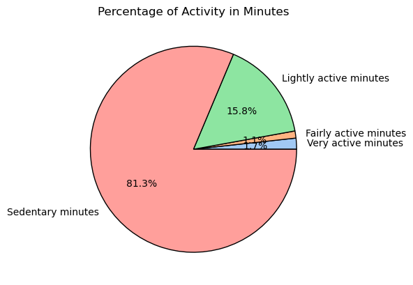

```python
# Calculate total of individual minutes column
very_active_mins = merged_df['VeryActiveMinutes'].sum()
fairly_active_mins = merged_df['FairlyActiveMinutes'].sum()
lightly_active_mins = merged_df['LightlyActiveMinutes'].sum()
sedentary_mins = merged_df['SedentaryMinutes'].sum()

# Plot the pie chart
slices = [very_active_mins, fairly_active_mins, lightly_active_mins, sedentary_mins]
labels = ["Very active minutes", "Fairly active minutes", "Lightly active minutes", "Sedentary minutes"]

plt.pie(slices,
        labels = labels,
        colors = sns.color_palette('pastel'),
        wedgeprops = {"edgecolor": "black"},
        autopct = "%1.1f%%")
plt.title("Percentage of Activity in Minutes")
plt.show()
```

As seen from the pie chart,

- Sedentary minutes takes the biggest slice at 81.3%.
- This indicates that users are using the FitBit app to log daily activities such as daily commute, inactive movements (moving from one spot to another) or running errands.
- App is rarely being used to track fitness (ie. running) as per the minor percentage of fairly active activity (1.1%) and very active activity (1.7%). This is highly discouraging as FitBit app was developed to encourage fitness.

### 4.1.2 Daily Steps by Week day

```python
# Set order for Week day
DayOfWeek_ordered = ['Monday', 'Tuesday', 'Wednesday', 'Thursday', 'Friday', 'Saturday', 'Sunday']
```

```python
# Calculate Average steps, group by Week day
weekday_steps = merged_df.groupby(['DayOfWeek']).mean()['TotalSteps'].reindex(DayOfWeek_ordered)
weekday_steps
```

```
DayOfWeek
Monday       7780.866667
Tuesday      8125.006579
Wednesday    7559.373333
Thursday     7405.836735
Friday       7448.230159
Saturday     8152.975806
Sunday       6933.231405
Name: TotalSteps, dtype: float64
```

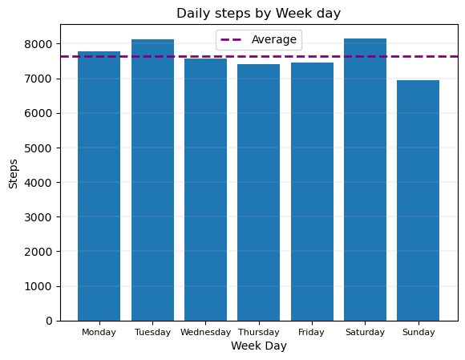

```python
# Plot Bar chart
plt.bar(x = DayOfWeek_ordered , height = weekday_steps)
plt.xlabel('Week Day')
plt.xticks(DayOfWeek_ordered, size = 8)
plt.ylabel('Steps')
plt.title('Daily steps by Week day')
plt.axhline(y=np.nanmean(weekday_steps), color='purple', linestyle='--', linewidth=2, label='Average')
plt.grid(axis = 'y', linewidth=0.2)
plt.legend()
plt.show()
```

According to results published in [JAMA Network Open](https://jamanetwork.com/journals/jamanetworkopen/fullarticle/2783711?utm_source=For_The_Media&utm_medium=referral&utm_campaign=ftm_links&utm_term=090321), those who took 7,000 steps or more a day on average were 50 percent to 70 percent less likely to die of any cause over the next decade, compared with those who took fewer steps. In the graphs above we can determine that users walk daily the recommended amount of steps of 7000 except for Sunday's.

### 4.1.3 Hourly steps throughout the day

```python
# View hourly_steps dataframe
hourly_steps.head()
```

|  | Id | ActivityHour | StepTotal | Date | Time |
| --- | --- | --- | --- | --- | --- |
| 0 | 1503960366 | 2016-04-12 00:00:00 | 373 | 2016-04-12 | 00:00:00 |
| 1 | 1503960366 | 2016-04-12 01:00:00 | 160 | 2016-04-12 | 01:00:00 |
| 2 | 1503960366 | 2016-04-12 02:00:00 | 151 | 2016-04-12 | 02:00:00 |
| 3 | 1503960366 | 2016-04-12 03:00:00 | 0 | 2016-04-12 | 03:00:00 |
| 4 | 1503960366 | 2016-04-12 04:00:00 | 0 | 2016-04-12 | 04:00:00 |

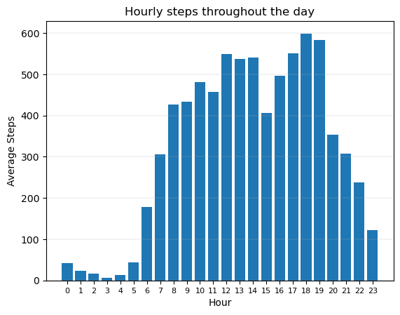

```python
# Plot Bar chart
h_steps = hourly_steps.groupby(['Time']).mean()['StepTotal'].reset_index()
time = range(0,24)

plt.bar(x = time , height = h_steps['StepTotal'])
plt.xlabel('Hour')
plt.xticks(time, size = 8)
plt.ylabel('Average Steps')
plt.title('Hourly steps throughout the day')
plt.grid(axis = 'y', linewidth=0.2)
plt.show()
```

From the bar chart above, it can be seen that people are more active between 8 am and 8 pm. Most activity happens during lunch time from 12pm to 2pm and evenings from 5pm and 7pm I suppose, that people go to a gym or for a walk after finishing work. We can use this time in the Bellabeat app to remind and motivate users to go for a run or walk

### 4.1.4 Daily Hours as sleep by Week day

```python
# Calculate Average Hours as sleep, group by Week day
weekday_sleep = merged_df.groupby(['DayOfWeek']).mean()['TotalHoursAsSleep'].reindex(DayOfWeek_ordered)
weekday_sleep
```

```
DayOfWeek
Monday       6.992391
Tuesday      6.742615
Wednesday    7.245606
Thursday     6.688438
Friday       6.757368
Saturday     6.985088
Sunday       7.546545
Name: TotalHoursAsSleep, dtype: float64
```

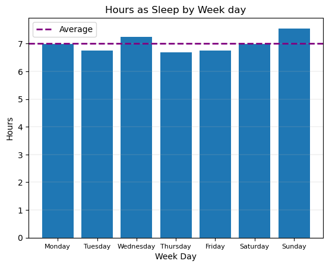

```python
# Plot Bar chart
plt.bar(x = DayOfWeek_ordered , height = weekday_sleep)
plt.xlabel('Week Day')
plt.xticks(DayOfWeek_ordered, size = 8)
plt.ylabel('Hours')
plt.title('Hours as Sleep by Week day')
plt.axhline(y=np.nanmean(weekday_sleep), color='purple', linestyle='--', linewidth=2, label='Average')
plt.grid(axis = 'y', linewidth=0.2)
plt.legend()
plt.show()
```